# Simple Linear Regression

Arjun Mannem

2023-11-07

```r
# Load necessary packages
library(tidyverse)
library(ggthemes)
library(flextable)
library(corrr)
library(ggfortify)
library(broom)
```

#### Set default theme settings for plots, and load a function to simplify table customization and creation using the code below.

```r
# Set ggplot theme for visualizations
theme_set(ggthemes::theme_few())

# Set options for flextables
set_flextable_defaults(na_str = "NA")

# Load function for printing tables nicely
source("https://raw.githubusercontent.com/dilernia/STA323/main/Functions/make_flex.R")
```

## Simple Linear Regression

a.Exploring monthly stock prices based on an economic indicator such as the gross domestic product (GDP) in U.S. dollars 📈

b.Analyzing the relationship between health outcomes of patients, e.g. blood pressure (mmHG), and the dosage level of a prescribed treatment in milligrams for lowering people’s blood-pressure ⚕️💊

**What are the response and predictor variables for examples a. and b. above?**

1. **Response Variable**: monthly stock prices

The assumed or theoretical simple linear regression model is

y = β0 + β1*x + ε,

where:

- y is the sales in U.S dollars
- β0 is the intercept
- β1 is the slope
- x is the amount spend on marketing/advertising in U.S. dollars
- ε is error / residual

**Correct**: Here slope is 2. So for every 1 dollar increase in advertising, we expect sales to increase by 2 dollars, on average.

**Incorrect**: Here slope is 2. So for every 1 dollar increase in advertising, sales increases by 2 dollars, on average.

**Further suppose for example d. that an estimated intercept was calculated as βHat0=5000. Interpret this value in the context of the problem.**

The expected amount of sales given that we are spending nothing on advertising is $5000.

**Given estimates of βHat0=5000 and βHat1=2 for example d., what would be predict our company’s sales revenue if we invested $500 in advertising on social media platforms?**

Given x = 500, βHat0=5000 and βHat1=2

y = βHat0 + βHat1 * x

y = 5000 + 2*500 = 6000

Estimated sales of the company in this scenario would be $6000.

## Example: Scrabble Letters

```r
# Importing data
scrabble <- read_csv("https://raw.githubusercontent.com/dilernia/STA323/main/Data/scrabble.csv")
# Printing table of data
scrabble %>%
  make_flex()
```

| letter | perc_rf_english_writing | scrabble_value |
| --- | --- | --- |
| A | 8.20 | 1.00 |
| B | 1.50 | 3.00 |
| C | 2.80 | 3.00 |
| D | 4.30 | 2.00 |
| E | 13.00 | 1.00 |
| F | 2.20 | 4.00 |
| G | 2.00 | 2.00 |
| H | 6.10 | 4.00 |
| I | 7.00 | 1.00 |
| J | 0.15 | 8.00 |
| K | 0.77 | 5.00 |
| L | 4.00 | 1.00 |
| M | 2.40 | 3.00 |
| N | 6.70 | 1.00 |
| O | 7.50 | 1.00 |
| P | 1.90 | 3.00 |
| Q | 0.10 | 10.00 |
| R | 6.00 | 1.00 |
| S | 6.30 | 1.00 |
| T | 9.10 | 1.00 |
| U | 2.80 | 1.00 |
| V | 0.98 | 4.00 |
| W | 2.40 | 4.00 |
| X | 0.15 | 8.00 |
| Y | 2.00 | 4.00 |
| Z | 0.07 | 10.00 |

#### Let’s look at a scatter plot and the correlations for the Scrabble data:

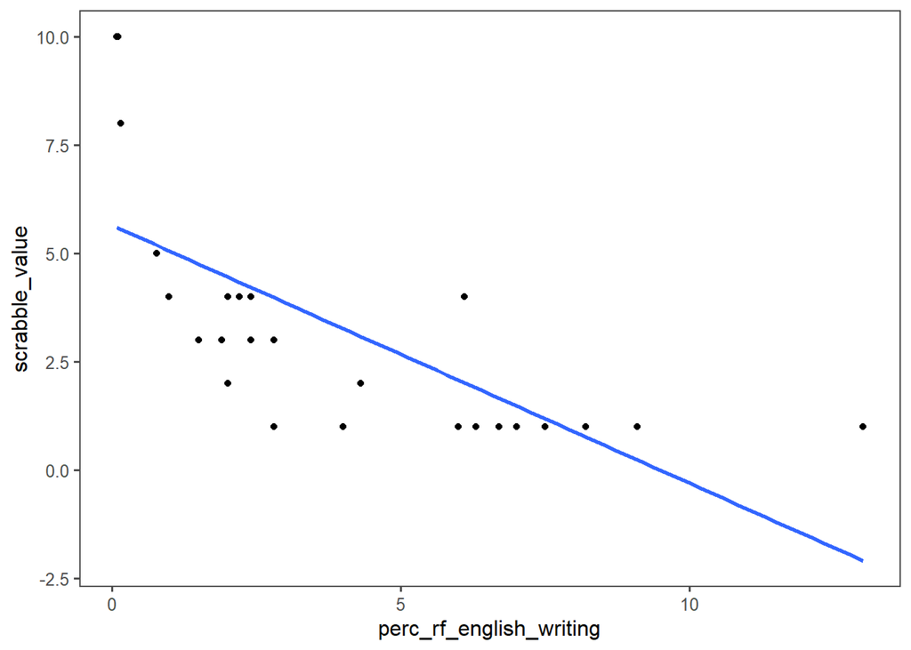

```r
# Creating a scatter plot
scrabble %>%
  ggplot(aes(x = perc_rf_english_writing,
             y = scrabble_value)) +
  geom_point() +
  geom_smooth(method = "lm", se = FALSE)
```

```r
# Calculating correlations
corTable <- scrabble %>%
  corrr::correlate(diagonal = 1)
```

```
## Non-numeric variables removed from input: `letter`
## Correlation computed with
## • Method: 'pearson'
## • Missing treated using: 'pairwise.complete.obs'
```

```r
# Printing table of correlations
corTable %>%
  make_flex(caption = "Table of pairwise correlations.")
```

Table 2: Table of pairwise correlations.

| term | perc_rf_english_writing | scrabble_value |
| --- | --- | --- |
| perc_rf_english_writing | 1.00 | -0.71 |
| scrabble_value | -0.71 | 1.00 |

**Does there appear to be a positive or negative relationship between the relative frequency of a letter in English writing (perc_rf_english_writing), and its Scrabble tile point value (scrabble_value)?**

Negative

**Does the sign (being positive or negative) of the correlation coefficient seem sensible in this context? Why or why not?**

Yes, the correlation being negative is sensible since a letter having higher percent relative frequency means it is easier to play in scrabble, so it should be worth less points.

**Does there appear to be a linear relationship between the relative frequency of a letter in English writing, and its Scrabble tile point value?**

No, the the relationship is non-linear, so truly simple linear regression is inappropriate, but we will proceed for the sake of the problem.

**Provide a statement of the assumed simple linear regression model for the Scrabble data.**

The assumed or theoretical simple linear regression model is

y = β0 + β1*x + ε,

where:

- y is the scrabble tile point value
- β0 is the intercept
- β1 is the slope
- x is the percent relative frequency of the letter in English writing
- ε is error / residual

#### Fit a simple linear regression model for the Scrabble data and print the model output using the code below.

```r
# Fitting a simple linear regression model
slrModel <- lm(scrabble_value ~ perc_rf_english_writing,
                data = scrabble)

# Printing model output
slrModel %>%
  broom::tidy() %>%
  make_flex()
```

| term | estimate | std.error | statistic | p.value |
| --- | --- | --- | --- | --- |
| (Intercept) | 5.64 | 0.61 | 9.18 | 2.5e-09 |
| perc_rf_english_writing | -0.59 | 0.12 | -4.89 | 5.5e-05 |

**Provide a statement of the estimated simple linear regression model for the Scrabble data.**

A statement of the estimated regression equation is

yHat = 5.64 - 0.59*x,

where:

yHat is the predicted Scrabble tile point value

βHat0 = 5.64 is the estimated intercept

βHat1 = -0.59 is the estimated slope

x is the percent relative frequency of a letter in English writing

**Provide and interpret the value of the coefficient of determination in context.**

r<sup>2</sup> = (-0.71)<sup>2</sup> = 0.5041

**General Blueprint Interpretation**

The proportion of the variability in y explained by x is *r<sup>2</sup>*;

**Scrabble example**

About 50.41% of the variability in the scrabble tile point values is explained by the percent relative frequencies of the letters in English writing.

or

The proportion of the variability in the scrabble tile point values is explained by the percent relative frequencies of the letters in English writing is 0.5041.

**Does our model explain significantly more of the variability in the response than an intercept only model? Why or why not?**

Since the p-value for the slope (5.5e-05) is less than 0.05, our model explain significantly more of the variability in the response than an intercept only model.